# Lake Mendota Freezing and Thawing

Bret Larget

Professor Jessi Cisewski Kehe contributed to these lecture notes.

## Overview

- Read the [chapter on Lake Mendota](https://bookdown.org/bret_larget/stat-240-case-studies/madison-lakes.html) from the Course Notes and Case Studies for background.

### Preliminaries

- For you to be able to run the code in this file, you need to put files in proper locations and set the working directory.
- Let `COURSE` represent your course directory.
1. Affirm that the directories `COURSE/lecture/` and `COURSE/lecture/unit2-ggplot2/` exist.
2. Download the file `lec-04-lake-mendota.Rmd` into the `unit2-ggplot2` sub-folder.
3. Affirm that the file `lake-mendota-winters-2022.csv` is in the `COURSE/data` folder.

## Read Data: Lake Mendota

```r
mendota = read_csv("../../data/lake-mendota-winters-2022.csv")
```

```r
## Add columns from the last lecture

## Fitting a model using code beyond the scope of this course
## The function `geom_smooth()` uses `loess()` under the hood
fit = loess(duration ~ year1, data = mendota)

## Add the values to the mendota data set
mendota = mendota %>%
  mutate(smooth_fitted = fit$fitted,
         smooth_residual = fit$residuals)
```

#### Mean and Standard Deviation

- When we learn about **dplyr** next week, we will develop some skills for summarizing data.
- This block of code calculates:
  - the mean and median of the residuals around the smooth curve (these are measures of the center of a distribution)
  - the standard deviation of the distribution (for a bell-shaped distribution, the standard deviation is the size of a “typical” distance from the mean).
  - several quantiles
- Do not worry about the code to produce these calculations until next week.

```r
mendota %>%
  summarize(mean = mean(smooth_residual),
            median = median(smooth_residual),
            sd = sd(smooth_residual),
            q10 = quantile(smooth_residual, 0.10),
            q25 = quantile(smooth_residual, 0.25),
            q50 = quantile(smooth_residual, 0.50),
            q75 = quantile(smooth_residual, 0.75),
            q90 = quantile(smooth_residual, 0.90))
```

```
## # A tibble: 1 × 8
##      mean median    sd   q10   q25   q50   q75   q90
##     <dbl>  <dbl> <dbl> <dbl> <dbl> <dbl> <dbl> <dbl>
## 1 -0.0577   2.22  16.7 -20.2 -8.16  2.22  10.7  18.8
```

- The mean of the distribution is close to 0
- The median is about 2 days above zero
- The standard deviation is 16.7 days, or a couple days longer than two weeks.
- Sometimes it is helpful to add vertical lines to a plot to help identify specific locations on the x axis.
- This next chunk of code adds vertical lines that are 1, 2, and 3 standard deviation below and above the center of zero.

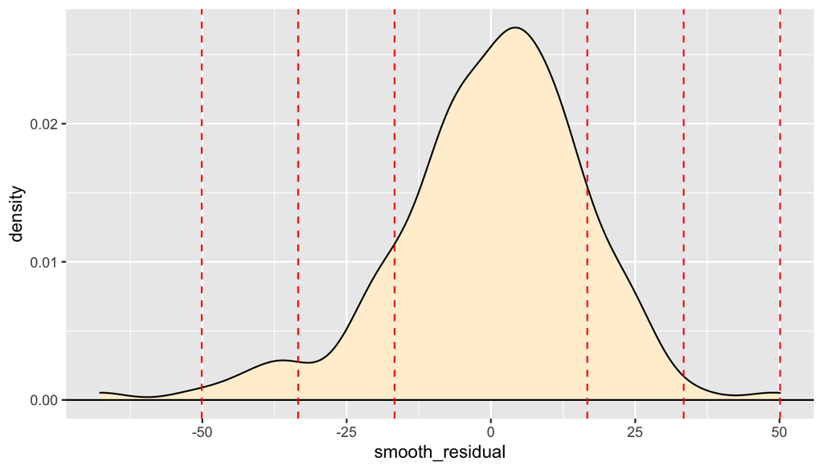

```r
ggplot(mendota, aes(x = smooth_residual)) +
  geom_density(fill = "papayawhip") +
  geom_hline(yintercept = 0) +
  geom_vline(xintercept = -3*16.7,
             color = "red", linetype = "dashed") +
  geom_vline(xintercept = -2*16.7,
             color = "red", linetype = "dashed") +
  geom_vline(xintercept = -1*16.7,
             color = "red", linetype = "dashed") +
  geom_vline(xintercept = 1*16.7,
             color = "red", linetype = "dashed") +
  geom_vline(xintercept = 2*16.7,
             color = "red", linetype = "dashed") +
  geom_vline(xintercept = 3*16.7,
             color = "red", linetype = "dashed")
```

- Symmetric bell-shaped solutions have the following approximate features (which are exactly true for an ideal normal distribution).
  - About 2/3 of the data is within one standard deviation of the mean, here between about 17 days above and below
  - About 95% of the observations are within two standard deviations of the mean
  - Nearly all of the observations are within three standard deviations of the mean
  - Here, our density is not perfectly ideal and there are likely a bit fewer than 95% of the values within two standard deviations with extras in the left tail of the distribution

### Axis Labels and Plot Titles

- Previous examples have shown how to use the commands `xlab()` and `ylab()` to modify the displayed axis labels in a plot.
- We have also shown how to use `ggtitle()` to add a title to a plot.
- When working interactively, it is fine to not worry about axis labels and plot titles: you know what the variables are and know what you are examining in the plot.
- However, when making a plot to present to someone else (or for yourself to look at in the future), it is best practice to create meaningful axis labels and a plot title.
  - **In particular, when creating plots for homework assignments, projects, or as part of a take-home exam, do make sure to create informative axis labels and plot titles.**
- The arguments to `xlab()` and `ylab()` are almost always just a simple text string, such as we have seen.
- You can suppress a label with the empty string `""`.
- In more advanced code we will not cover, you can:
  - modify font size and type
  - use greek symbols or mathematical notation
  - create labels which include variables that can change if the values do
- Usually, plot titles made with `ggtitle()` are also just a simple string as an argument.
- The example below also uses the argument `subtitle` to add a second line to the displayed title in a smaller font.
  - This is especially useful when an informative title is too long for a single line.

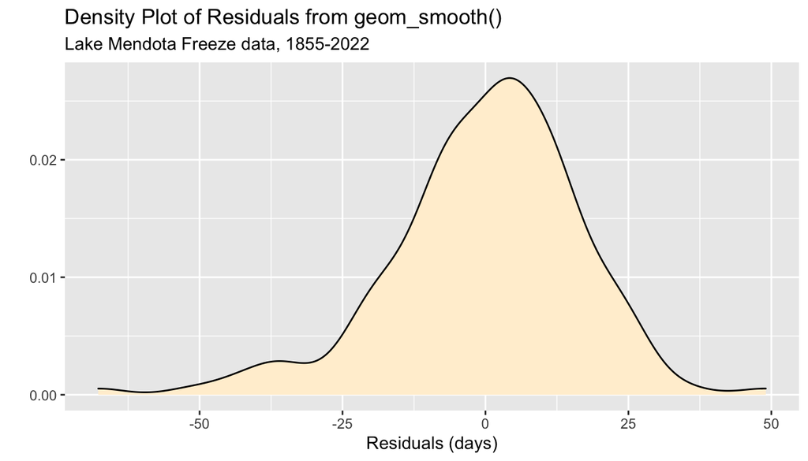

```r
ggplot(mendota, aes(x = smooth_residual)) +
  geom_density(fill = "papayawhip") +
  xlab("Residuals (days)") +
  ylab("") +
  ggtitle("Density Plot of Residuals from geom_smooth()",
          subtitle = "Lake Mendota Freeze data, 1855-2022")
```

### Question 3

> When in the winter does Lake Mendota typically close with ice the first time?
- To answer this question graphically, I decided to create a new variable which categorizes the date of the first freeze into a half-month time period, from “Nov 16-30” through “Jan 16-31”
  - (the earliest date Lake Mendota closed with ice was November 23 during the winter of 1880-81 and the latest date Lake Mendota closed with ice was January 30 during the winter of 1931-32).
- The variable `ff_x` counts the number of days after June 30 of the corresponding winter.
  - For example, November 30 is 153 days after June 30 each year.
- The following block of code uses commands from **dplyr** to transform the data by adding new columns, **lubridate** to work with dates, and **stringr** to work with strings.
- **Do not worry about this code yet.**

```r
mendota = mendota %>%
  mutate(ff_x = as.integer(first_freeze -
                             ymd(str_c(year1,"-06-30"))),
         ff_cat = case_when(
           ff_x <= 153 ~ "Nov 16-30",
           ff_x <= 168 ~ "Dec 1-15",
           ff_x <= 184 ~ "Dec 16-31",
           ff_x <= 199 ~ "Jan 1-15",
           ff_x <= 215 ~ "Jan 16-30")) %>%
  mutate(ff_cat = reorder(ff_cat, ff_x))

mendota_sum = mendota %>%
  count(ff_cat)
```

- Our new variable of interest is named `ff_cat` and it categorizes the date of the first freeze.
- We also have a new summary data frame named `mendota_sum` with the counts of how many winters fall into each category.

```r
mendota %>%
  select(winter, duration, first_freeze, ff_cat) %>%
  slice_head(n=5)
```

```
## # A tibble: 5 × 4
##   winter  duration first_freeze ff_cat
##   <chr>      <dbl> <date>       <fct>
## 1 1855-56      118 1855-12-18   Dec 16-31
## 2 1856-57      151 1856-12-06   Dec 1-15
## 3 1857-58      121 1857-11-25   Nov 16-30
## 4 1858-59       96 1858-12-08   Dec 1-15
## 5 1859-60      110 1859-12-07   Dec 1-15
```

```r
mendota_sum
```

```
## # A tibble: 5 × 2
##   ff_cat        n
##   <fct>     <int>
## 1 Nov 16-30     4
## 2 Dec 1-15     47
## 3 Dec 16-31    80
## 4 Jan 1-15     34
## 5 Jan 16-30     2
```

### Bar Graphs

- A bar graph is a common way to display the counts of a categorical variable.
- The **ggplot2** command `geom_bar()` is used to create bar graphs from a data set where the heights of the bars need t be calculated.
- In contrast, the **ggplot2** command `geom_col()` is used when there is one column for the categorical variable and another column which contains the heights of the bars.

#### geom_bar()

- This code creates a bar graph from the `ff_cat` variable of the `mendota` data set.
  - The bar heights are calculated by counting the number of winters in each category.

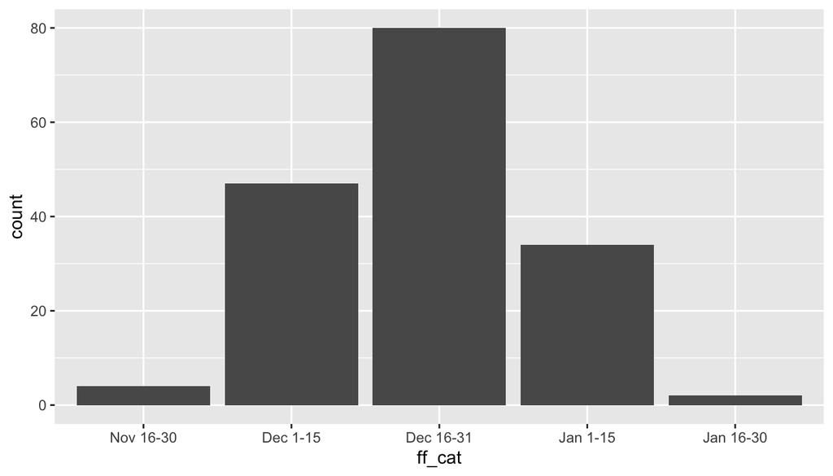

```r
ggplot(mendota, aes(x = ff_cat)) +
  geom_bar()
```

- We can add layers to improve the appearance.

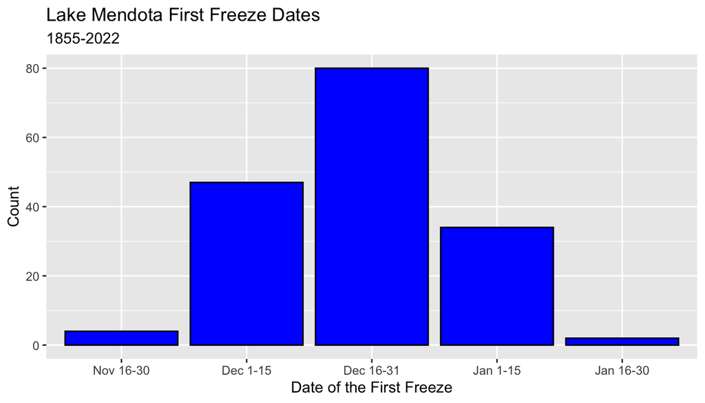

```r
ggplot(mendota, aes(x = ff_cat)) +
  geom_bar(color = "black", fill = "blue") +
  xlab("Date of the First Freeze") +
  ylab("Count") +
  ggtitle("Lake Mendota First Freeze Dates",
          subtitle = "1855-2022")
```

#### geom_col()

- Here a table with the summary counts

```r
mendota_sum
```

```
## # A tibble: 5 × 2
##   ff_cat        n
##   <fct>     <int>
## 1 Nov 16-30     4
## 2 Dec 1-15     47
## 3 Dec 16-31    80
## 4 Jan 1-15     34
## 5 Jan 16-30     2
```

- Use `geom_col()` and set both `x` and `y` aesthetics.

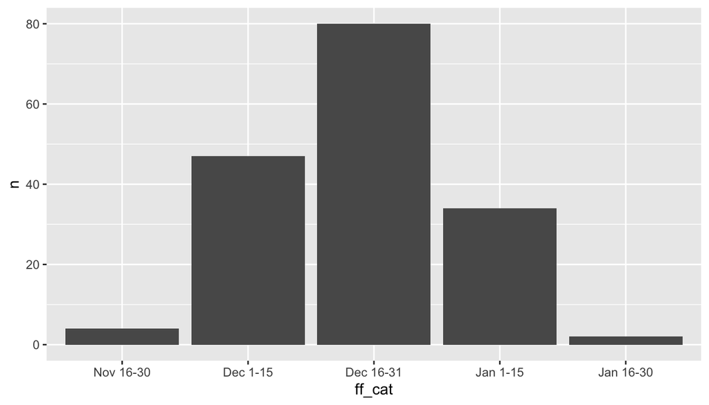

```r
ggplot(mendota_sum, aes(x = ff_cat, y = n)) +
  geom_col()
```

- Again, make the graph better for presentation.

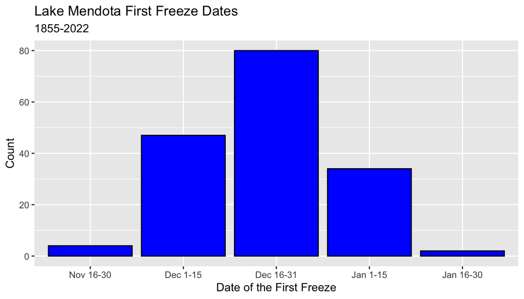

```r
ggplot(mendota_sum, aes(x = ff_cat, y = n)) +
  geom_col(color = "black", fill = "blue") +
  xlab("Date of the First Freeze") +
  ylab("Count") +
  ggtitle("Lake Mendota First Freeze Dates",
          subtitle = "1855-2022")
```

### Facets

- Facets are a way to partition a data set according to one or two categorical variables
- Each part of the data is displayed in its own panel (facet) of a common plot.
- Typically, the axes are consistent for all facets, but this can be relaxed.
- To demonstrate faceting, we add a new categorical variable `period50` which divides the years into 50-year periods.
- **The code in this block will be described next week.**

```r
mendota = mendota %>%
  mutate(period50 = case_when(
    year1 < 1901 ~ "1855-1900",
    year1 < 1951 ~ "1901-1950",
    year1 < 2001 ~ "1951-2000",
    TRUE ~ "2001-2022"))
```

#### facet_wrap()

- The command `facet_wrap()` partitions the data by one or more categorical variables
- Each different combination of values receives it own facet.
- The computer decides how to break the collection of facets into separate rows
- Use the function `vars()` to list the variable on which to facet.
  - The old-style syntax used a formula, such as `~period50` to specify the faceting variable.
  - I am working on forgetting this old syntax
- Here, the four facets are broken into two rows of two

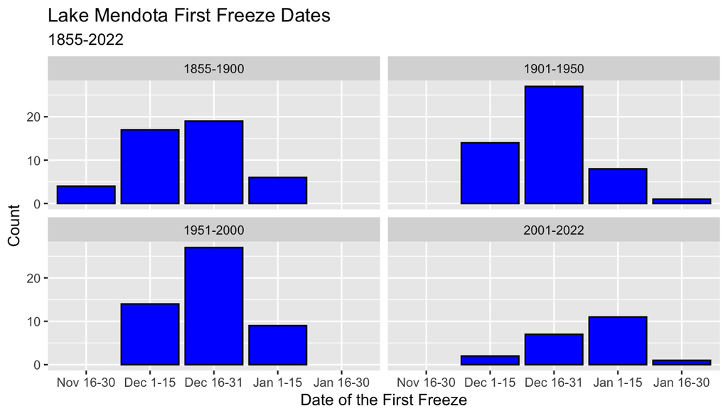

```r
ggplot(mendota, aes(x = ff_cat)) +
  geom_bar(color = "black", fill = "blue") +
  xlab("Date of the First Freeze") +
  ylab("Count") +
  ggtitle("Lake Mendota First Freeze Dates",
          subtitle = "1855-2022") +
  facet_wrap(vars(period50))
```

- You can see more examples at the [tidyverse reference page for `facet_wrap()`](https://ggplot2.tidyverse.org/reference/facet_wrap.html)

#### facet_grid()

- The command `facet_grid()` is used when you want to organize the rows and/or columns of the facets by one or more variables.
- This example forces the facets to use a different row for each value of `period50`.

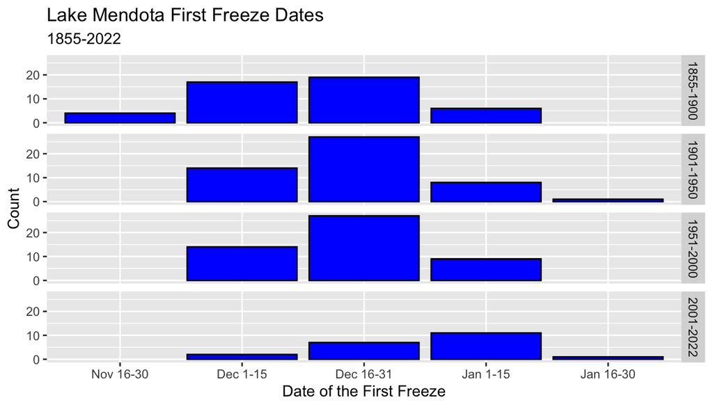

```r
ggplot(mendota, aes(x = ff_cat)) +
  geom_bar(color = "black", fill = "blue") +
  xlab("Date of the First Freeze") +
  ylab("Count") +
  ggtitle("Lake Mendota First Freeze Dates",
          subtitle = "1855-2022") +
  facet_grid(rows = vars(period50))
```

- Here, the output uses a different column for each value of `period50`.
- The axis labels might get crowded!

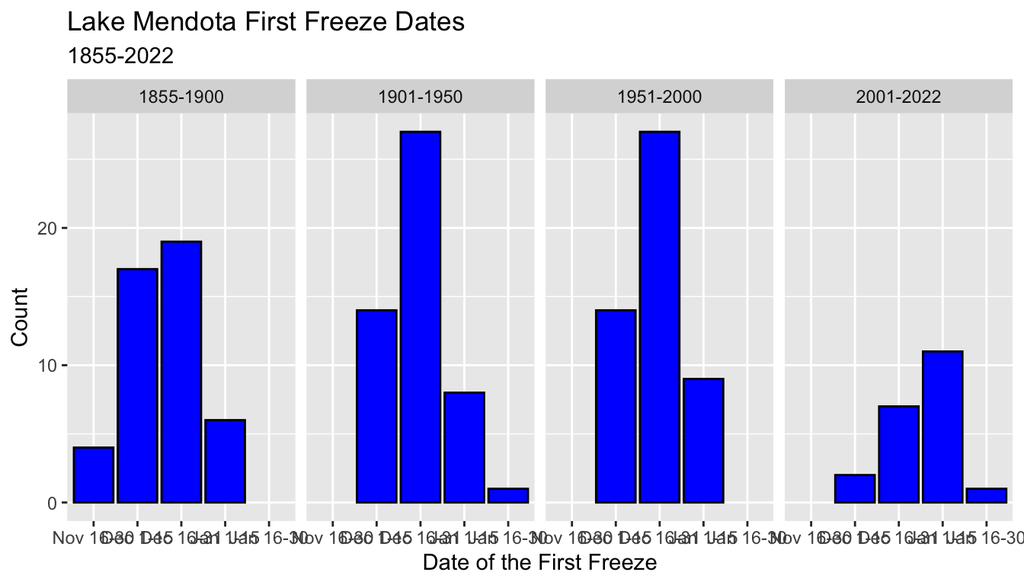

```r
ggplot(mendota, aes(x = ff_cat)) +
  geom_bar(color = "black", fill = "blue") +
  xlab("Date of the First Freeze") +
  ylab("Count") +
  ggtitle("Lake Mendota First Freeze Dates",
          subtitle = "1855-2022") +
  facet_grid(cols = vars(period50))
```

- For a single variable, `facet_wrap()` usually is preferable.
- For a different data set where breaking up by two different categorical variables, `facet_grid()` can be very useful.
- You can see more examples at the [tidyverse reference page for `facet_grid()`](https://ggplot2.tidyverse.org/reference/facet_grid.html)

### Scales

- There are a number of ways to change the scales used by the axes
- These notes will simply introduce a few examples
- We begin by creating another summary of the `mendota` data set
  - we `count()` the number of observations within each 50-year period and first freeze 2-week category in a column `n`
  - the column `p` is the proportion of these counts within each 50-year period
  - the column `pct` are these values as percentages
- **We will discuss this code next week**

```r
mendota_sum2 = mendota %>%
  count(period50, ff_cat) %>%
  group_by(period50) %>%
  mutate(p = n / sum(n),
         pct = 100*p)

mendota_sum2 %>%
  print(n = Inf)
```

```
## # A tibble: 15 × 5
## # Groups:   period50 [4]
##    period50  ff_cat        n      p   pct
##    <chr>     <fct>     <int>  <dbl> <dbl>
##  1 1855-1900 Nov 16-30     4 0.0870  8.70
##  2 1855-1900 Dec 1-15     17 0.370  37.0
##  3 1855-1900 Dec 16-31    19 0.413  41.3
##  4 1855-1900 Jan 1-15      6 0.130  13.0
##  5 1901-1950 Dec 1-15     14 0.28   28
##  6 1901-1950 Dec 16-31    27 0.54   54
##  7 1901-1950 Jan 1-15      8 0.16   16
##  8 1901-1950 Jan 16-30     1 0.02    2
##  9 1951-2000 Dec 1-15     14 0.28   28
## 10 1951-2000 Dec 16-31    27 0.54   54
## 11 1951-2000 Jan 1-15      9 0.18   18
## 12 2001-2022 Dec 1-15      2 0.0952  9.52
## 13 2001-2022 Dec 16-31     7 0.333  33.3
## 14 2001-2022 Jan 1-15     11 0.524  52.4
## 15 2001-2022 Jan 16-30     1 0.0476  4.76
```

- When we created bar graphs of the first freeze date 2-week categories by 50-year period of the counts, the overall size of the histograms was smaller in the two parts with fewer observations.
- Here we use `geom_bar()` from the winter-level data as above

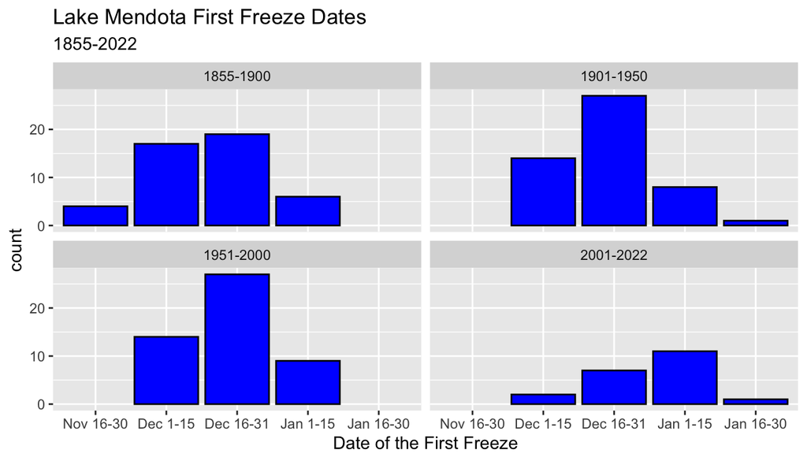

```r
ggplot(mendota, aes(x = ff_cat)) +
  geom_bar(color = "black", fill = "blue") +
  xlab("Date of the First Freeze") +
  ggtitle("Lake Mendota First Freeze Dates",
          subtitle = "1855-2022") +
  facet_wrap(vars(period50))
```

- To make it easier to compare the histograms, we may have wanted to display percentages in each group rather than the raw counts.
- Here we use the summary data and plot the percentages from `pct` on the y axis
- This makes it easier to compare the bar graphs ignoring the differences in the total number of observations

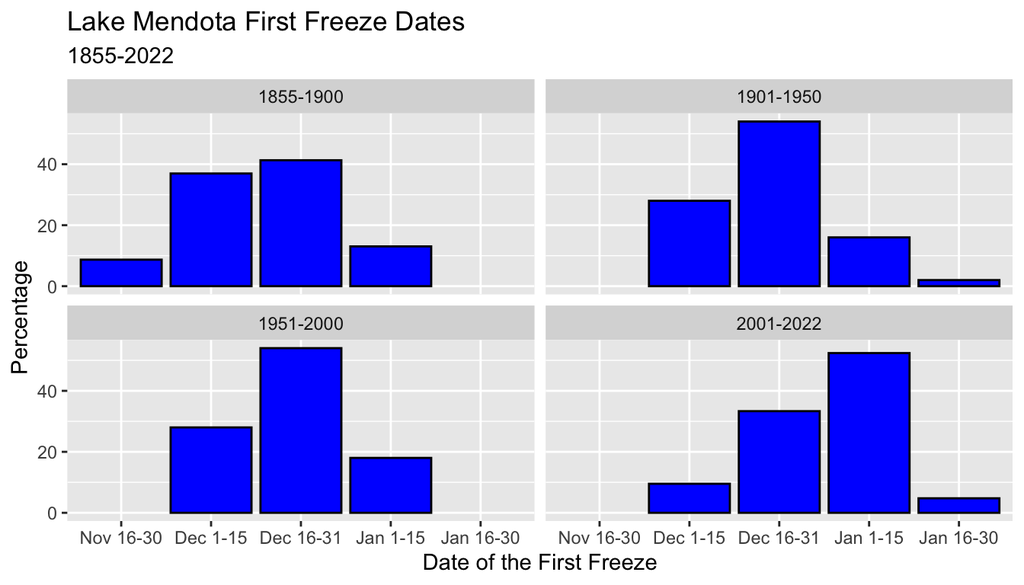

```r
ggplot(mendota_sum2, aes(x = ff_cat, y = pct)) +
  geom_col(color = "black", fill = "blue") +
  xlab("Date of the First Freeze") +
  ylab("Percentage") +
  ggtitle("Lake Mendota First Freeze Dates",
          subtitle = "1855-2022") +
  facet_wrap(vars(period50))
```

- Finally, this last graph introduces the command `scale_y_continuous()` to change the labels on the y axis to percentages
- Note that we use the proportions (between 0 and 1) as the data (`y = p`), but that changing the labels to percentages adjusts by multiplying by 100 automatically.

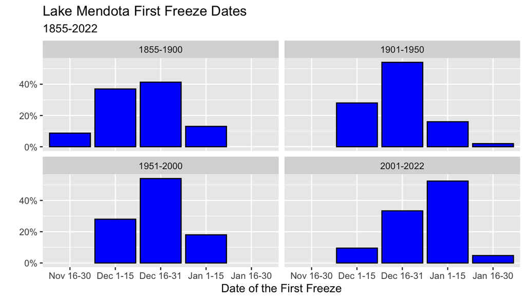

```r
ggplot(mendota_sum2, aes(x = ff_cat, y = p)) +
  geom_col(color = "black", fill = "blue") +
  scale_y_continuous(labels = scales::percent) +
  xlab("Date of the First Freeze") +
  ylab("") +
  ggtitle("Lake Mendota First Freeze Dates",
          subtitle = "1855-2022") +
  facet_wrap(vars(period50))
```

- We will see many other changes to scales in future lectures.
- Other examples of `scale_*()` commands include `scale_y_discrete()`, `scale_x_continuous()`, `scale_x_discrete()`.
- The continuous scale commands can be used to change the scales after transformations, such as using logarithmic scales
- These commands can also be used to modify where the and how the axes are labelled.
- Here is an example which replaces the `ff_x` values (number of days after June 30) with the actual dates.
- Note also the use of saving a `ggplot()` object and then reusing it
  - This is handy when you want to reuse most of the commands for several plots.

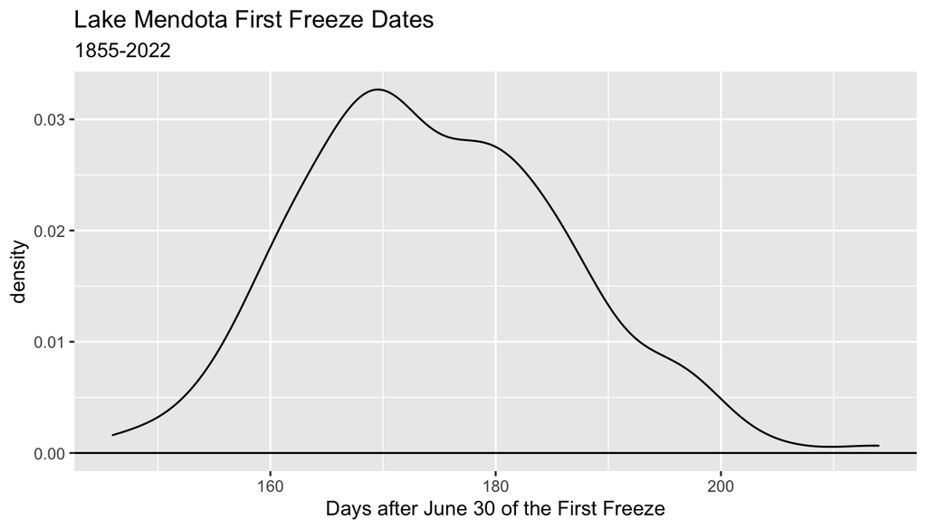

```r
## ff_x directly
g = ggplot(mendota, aes(x = ff_x)) +
  geom_density() +
  geom_hline(yintercept = 0) +
  xlab("Days after June 30 of the First Freeze") +
  ggtitle("Lake Mendota First Freeze Dates",
          subtitle = "1855-2022")

g
```

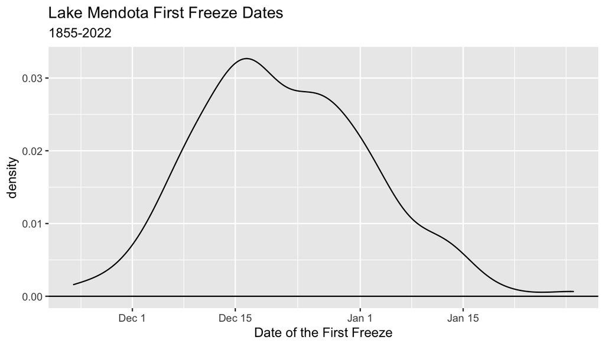

```r
## relabeled axes
## lubridate commands (ignore for now!)
dec01 = as.numeric(ymd("2022-12-01") - ymd("2022-06-30"))
dec15 = as.numeric(ymd("2022-12-15") - ymd("2022-06-30"))
jan01 = as.numeric(ymd("2023-01-01") - ymd("2022-06-30"))
jan15 = as.numeric(ymd("2023-01-15") - ymd("2022-06-30"))

g +
  scale_x_continuous(breaks = c(dec01, dec15, jan01, jan15),
                     labels = c("Dec 1", "Dec 15", "Jan 1", "Jan 15")) +
  xlab("Date of the First Freeze")
```

- There are also `scale_*()` commands for other aesthetics such as color, fill, and size.

### Adding Color

- Color is a useful aesthetic which can be used to add information from a categorical variable (and sometimes a numerical variable) to a plot.
- Here, we make a trace plot of the total duration that Lake Mendota is closed by ice versus the year, but add color to indicate the half-month period of time of the date when Lake Mendota was first closed by ice

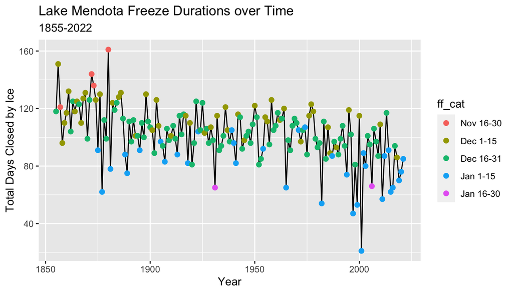

```r
g = ggplot(mendota, aes(x = year1, y = duration)) +
  geom_line() +
  geom_point(aes(col = ff_cat), size = 2) +
  xlab("Year") +
  ylab("Total Days Closed by Ice") +
  ggtitle("Lake Mendota Freeze Durations over Time",
          subtitle = "1855-2022")

g
```

- The default color scheme in `ggplot2` is not friendly to color blind people.
  - Red and green are difficult for many people to discern, and these are two colors in the default scale.
- This example uses colors from a scale named “viridis” designed to more evenly spread colors across a continuous range for which the perceptions are similar for most types of color blindness.

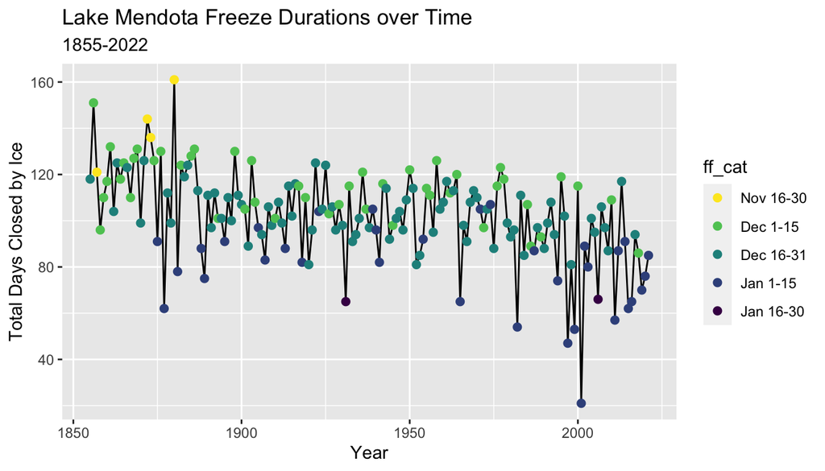

```r
g = g +
  scale_color_viridis_d(direction = -1)

g
```

### Guides

- We make a few other improvements to the plot
- The legend title uses the local variable name `ff_cat`. A better choice for presentation would be something like “First Freeze Time”.
- The command `guides()` allows many customization of the legends (guides) which accompany plots.
- The example here changes the title of the color guide.

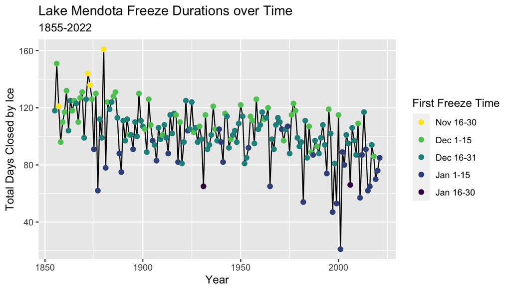

```r
g = g +
  guides(color = guide_legend(title = "First Freeze Time"))

g
```

- More examples on modifying the guides with a plot are in the [tidyverse reference guides page](https://ggplot2.tidyverse.org/reference/guides.html)

### Themes

- The default theme for plots in **ggplot2** uses a gray background with white lines to display breaks
- There are many different themes to choose from
- Here is an example which switches to a black and white these with a white background and light gray break lines

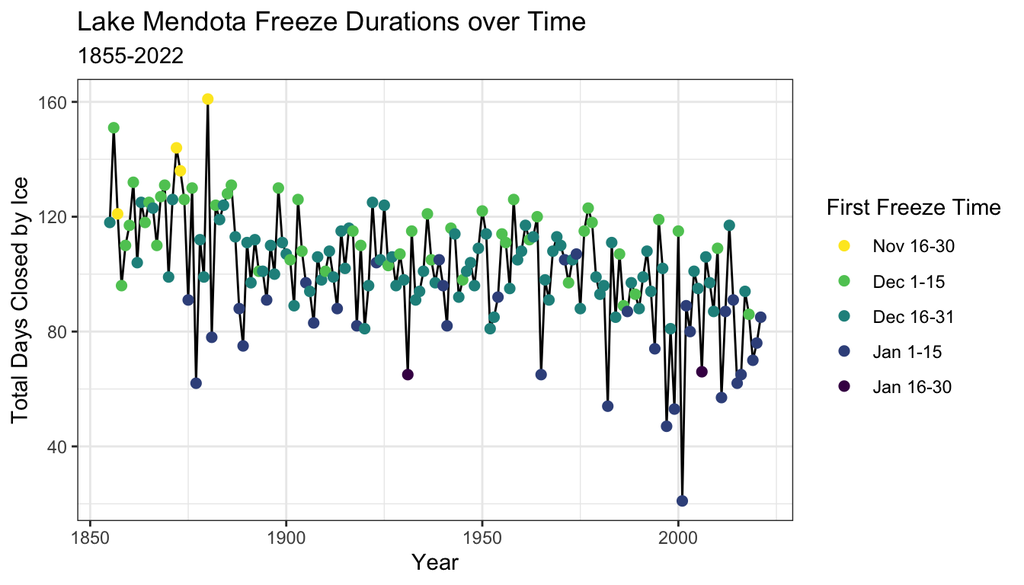

```r
g + theme_bw()
```

- An alternative is a minimal theme which eliminates the box which outlines the plotting area.

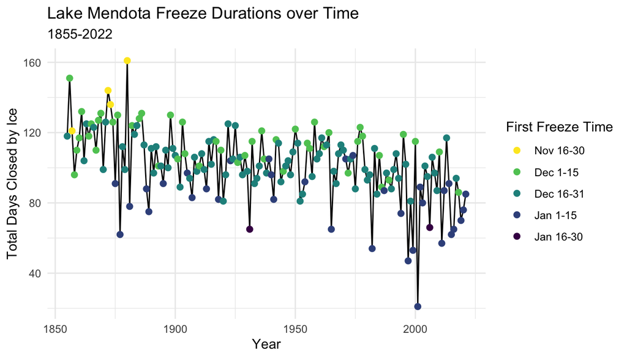

```r
g + theme_minimal()
```

- The [tidyverse list of complete themes](https://ggplot2.tidyverse.org/reference/ggtheme.html) are part of the tidyverse online reference.
- More examples on modifying themes are in the [tidyverse reference guides page](https://ggplot2.tidyverse.org/reference/theme.html)

## Summary

- Plotting is an essential component of data analysis
  - We will practice the **ggplot2** skills you are just now learning throughout the semester
  - We will continue to learn new enhancements to the collection of **ggplot2** commands as the semester continues, even while we focus on learning other aspects of data analysis

### Basics

- Begin all plots with `ggplot()`
  - Typically the call to `ggplot()` will specify:
    - the data set (`data` is the first argument), and
    - the mapping of variables to aesthetics with `aes()` (`mapping` is the second argument)

### Aesthetics

- Aesthetics such as `x`, `y`, `color`, `size`, and `shape` which vary according to the values of variables are mapped to these variables with the function `aes()`
  - Mappings in `ggplot()` carry over to all subsequent layers
  - Aesthetics may be added or replaced with the mapping argument in a specific layer command

### Geoms

- There are different “geometries” which define how data is presented
- Examples we have seen so far include:
  - Histograms with `geom_histogram()`
  - Density plots with `geom_density()`
  - Box plots with `geom_boxplot()`
  - Scatter plots with `geom_point()`
  - Trace plots with `geom_line()`
  - Bar graphs with `geom_bar()` when the function does the counting
  - Bar graphs with `geom_col()` when you supply the bar heights
- There are many more examples.

### Facets

- A single plot may partition the data into parts and display each part in its own facet (panel)
- Use `facet_wrap()` to display a sequence of facets in rows, letting the computer decide where to break the rows
- Use `facet_grid()` when you want to decide which variables vary by rows and columns in the displays

### Color

- You can use color to add information from categorical variables (typically, but numerical sometimes too) to points, lines, or other geometries (such as fill color in box plots)
- Consider using `viridis` or other color sales regularly instead of default values

### Scales

- Functions such as `scale_y_continuous()`, `scale_x_discrete()` and `scale_color_discrete()` (among many others) can maodify the defaults for how aesthetics are displayed in a plot.
- We will see more during the semester
- There are many more features than we will cover this semester.

### Guides

- Use the `guides()` function to control the guides for aesthetics in a plot
  - We have shown how to change a title
  - There are many more features which can be changed

### Themes

- The standard theme has a gray background and white break lines
- `theme_bw()` changes to a black and white theme
- `theme_minimal()` removes the boundary box around the plot and also uses a black and white theme
- There are many, many more options and you can customize